# Flight Delays Prediction / Analytics

### Ploting the results

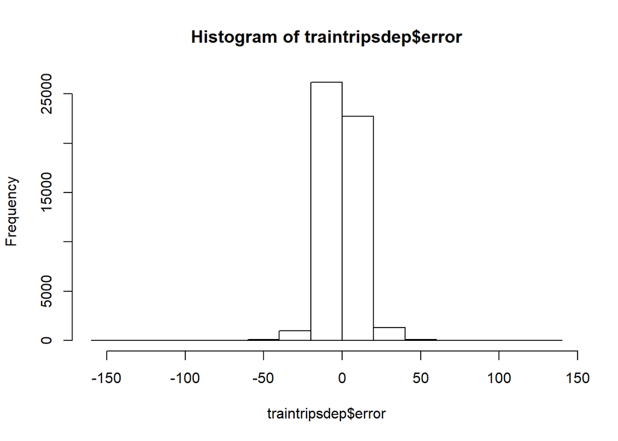

```r
# Check residual plots
hist(traintripsdep$error)
```

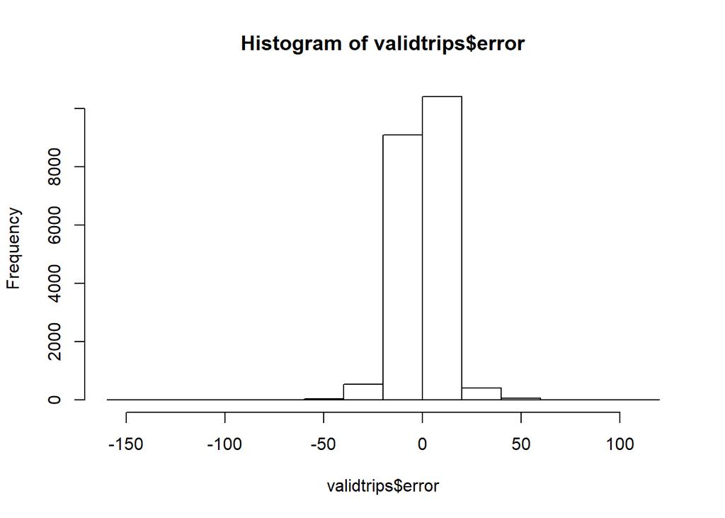

```r
hist(validtrips$error)
```

In both cases the histogram is centered at zero. Espicially with Test data. This is a good test. Follows nornal distribution which is a good measure of model performance.

#### Corelation

```r
# Correlation
a<-cor(traintripsdep$DepDelay,
       traintripsdep$pred.DepDelay )
b<-cor(validtrips$DepDelay,
       validtrips$predict.DepDelay )
a
```

```
## [1] 0.9721938
```

```r
b
```

```
## [1] 0.9724864
```

```r
a*a
```

```
## [1] 0.9451608
```

```r
b*b
```

```
## [1] 0.9457298
```

#### Corelation between actul and predicted is very high satisfying the accuracy of the model.

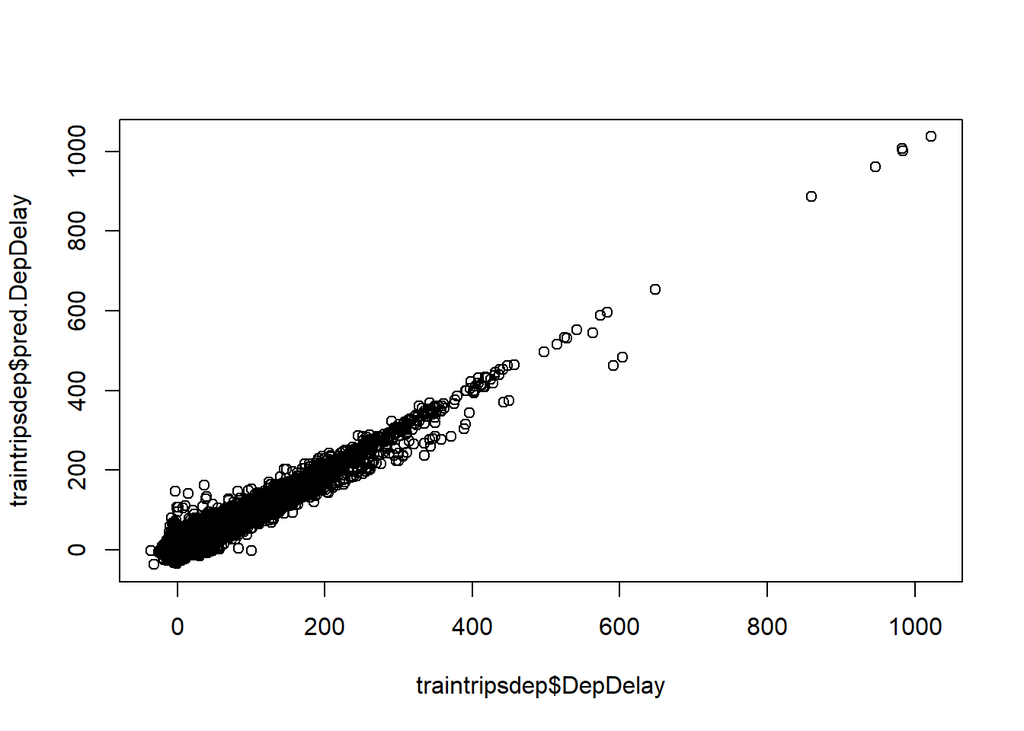

```r
plot(traintripsdep$DepDelay,
     traintripsdep$pred.DepDelay )
```

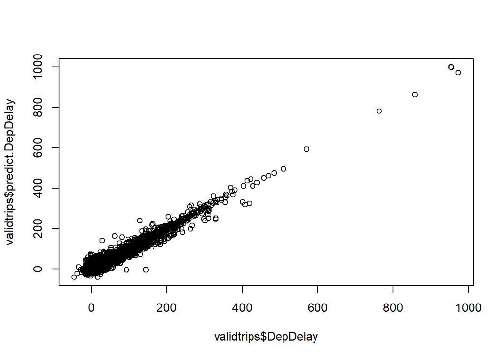

```r
plot(validtrips$DepDelay,
     validtrips$predict.DepDelay )
```

If we look at the Actual vs Predicted it almost follows stright line over diaognal.

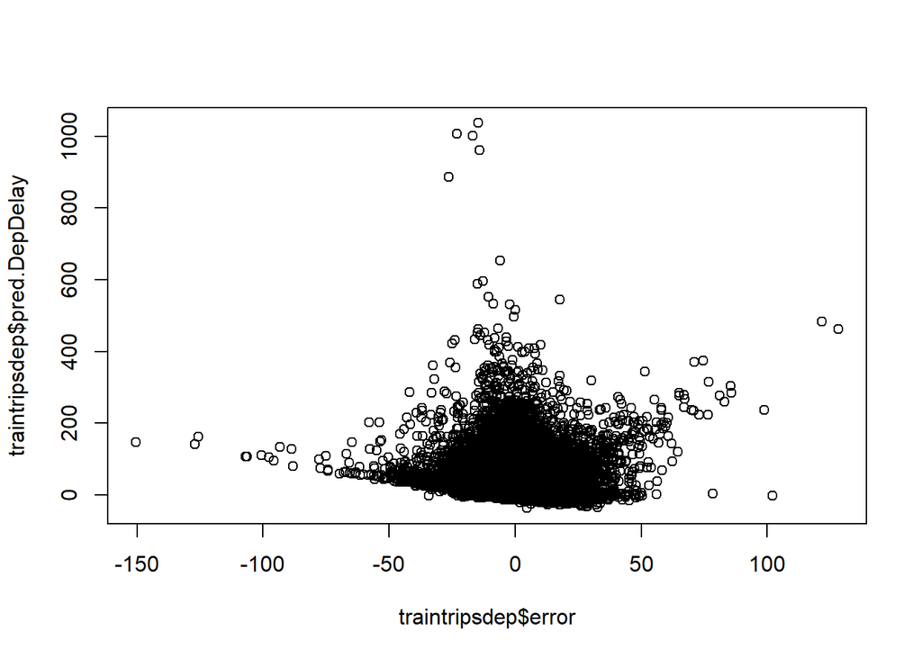

```r
plot(traintripsdep$error,
     traintripsdep$pred.DepDelay )
```

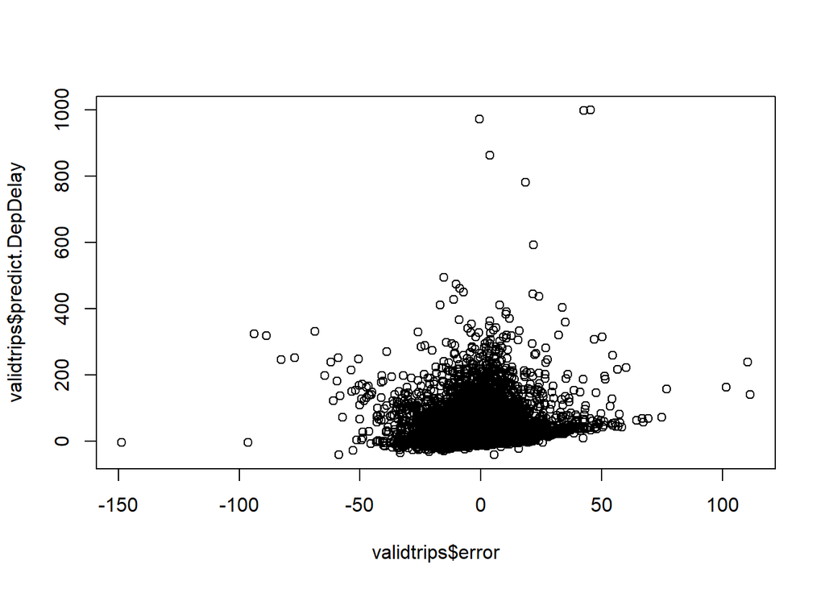

```r
plot(validtrips$error,
     validtrips$predict.DepDelay )
```

Follows normal distributuon. Model performance is good and accuracy is good as well.

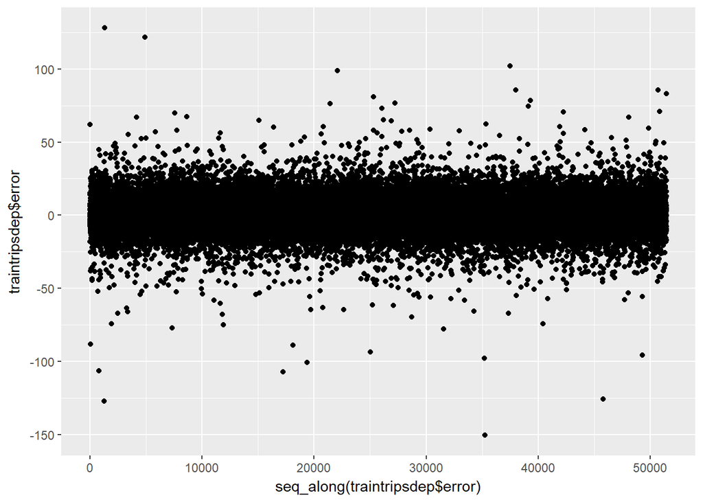

```r
qplot(y=traintripsdep$error)
```

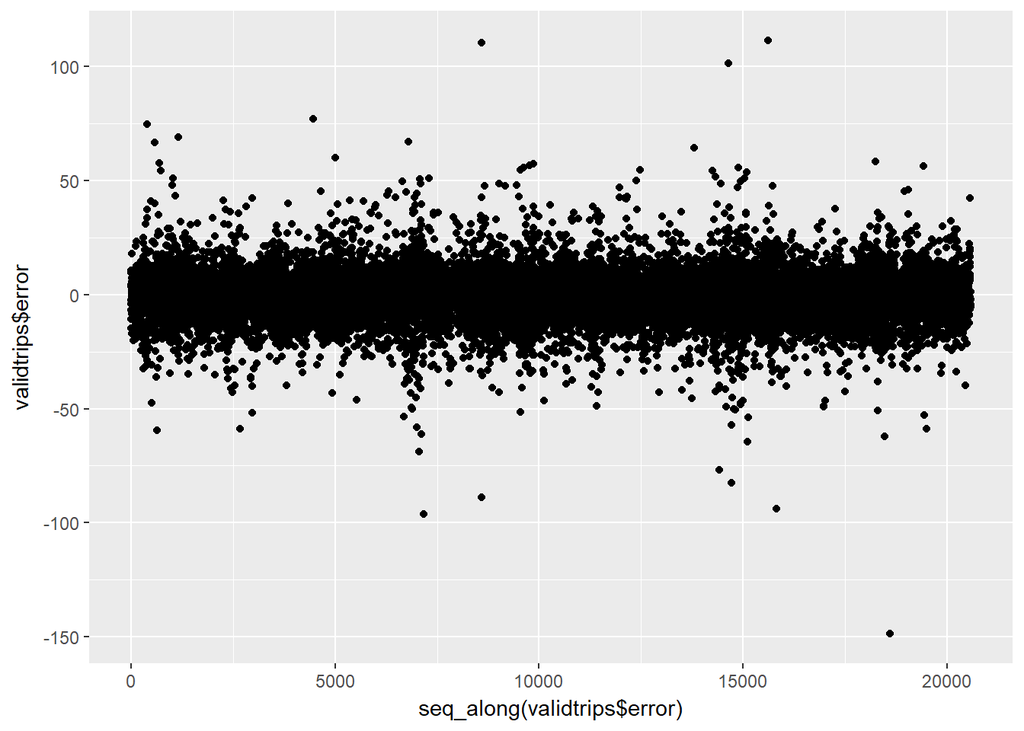

```r
qplot(y=validtrips$error)
```

There are very few outliers which is good as well.

Though we have tested each and every independent variable and max combinations before choosing final model. We can use alternate methods to choose variables. One of such methods is AIC. This takes combinations of variables and computes statistics. We have run STEP AIC and even with the first model seems to be best. Not showing STEPAIC here to save some real estate. In the actual code file we hae it.

### Now it’s time to predict ArrDelay as well. We can use DespDelay as well for predicting Arrival Delay.

Here, we can assume that DepDelay information is available and predict!. There is strong co-relation between two. This will be a very good predictor. Also, later we will make DepDelay not available and predict.

```r
traintripsArr <- traintrips
#traintripsArr <- traintrips[, !grepl("DepDelay" , names(traintrips))]  # Removing Arrvilal related variables.

lm.arr.fit1 <- stats::lm(ArrDelay ~ . , data=traintripsArr)
summary(lm.arr.fit1)
```

```
##
## Call:
## stats::lm(formula = ArrDelay ~ ., data = traintripsArr)
##
## Residuals:
##     Min      1Q  Median      3Q     Max
## -56.524  -3.632   0.663   4.344  73.937
##
## Coefficients: (14 not defined because of singularities)
##                              Estimate Std. Error t value Pr(>|t|)
## (Intercept)                 11.848986   1.265347   9.364  < 2e-16 ***
## `as.factor(Month)2`          0.305081   0.165131   1.848 0.064678 .
## `as.factor(Month)3`         -0.411769   0.159625  -2.580 0.009894 **
## `as.factor(Month)4`         -0.325130   0.164019  -1.982 0.047454 *
## `as.factor(Month)5`         -0.210229   0.161360  -1.303 0.192630
## `as.factor(Month)6`          0.285234   0.159955   1.783 0.074557 .
## `as.factor(Month)7`          0.031198   0.159612   0.195 0.845034
## `as.factor(Month)8`         -0.178059   0.161333  -1.104 0.269738
## `as.factor(Month)9`         -1.378939   0.166398  -8.287  < 2e-16 ***
## `as.factor(Month)10`        -0.743459   0.164217  -4.527 5.99e-06 ***
## `as.factor(Month)11`        -1.395836   0.166771  -8.370  < 2e-16 ***
## `as.factor(Month)12`         0.159323   0.161335   0.988 0.323388
## `as.factor(DayOfWeek)2`     -0.326764   0.120348  -2.715 0.006627 **
## `as.factor(DayOfWeek)3`      0.079935   0.119731   0.668 0.504379
## `as.factor(DayOfWeek)4`      0.424312   0.119436   3.553 0.000382 ***
## `as.factor(DayOfWeek)5`      0.392230   0.118885   3.299 0.000970 ***
## `as.factor(DayOfWeek)6`     -0.884514   0.125051  -7.073 1.53e-12 ***
## `as.factor(DayOfWeek)7`     -0.124541   0.121034  -1.029 0.303499
## UniqueCarrierAQ             -0.364422   0.638397  -0.571 0.568111
## UniqueCarrierAS             -0.528561   0.340339  -1.553 0.120419
## UniqueCarrierB6             -1.401038   0.263164  -5.324 1.02e-07 ***
## UniqueCarrierCO             -1.570134   0.219084  -7.167 7.78e-13 ***
## UniqueCarrierDL             -0.383004   0.229684  -1.668 0.095416 .
## UniqueCarrierEV             -0.218193   0.276026  -0.790 0.429250
## UniqueCarrierF9              1.285277   0.329724   3.898 9.71e-05 ***
## UniqueCarrierFL              0.904145   0.253111   3.572 0.000354 ***
## UniqueCarrierHA              1.439818   0.563971   2.553 0.010683 *
## UniqueCarrierMQ              0.723165   0.195543   3.698 0.000217 ***
## UniqueCarrierNW              1.773322   0.264010   6.717 1.88e-11 ***
## UniqueCarrierOH              0.263472   0.274378   0.960 0.336933
```

[output cut: 169 more lines]

```
## `as.factor(Originstate)WI`   0.248984   0.674306   0.369 0.711946
## `as.factor(Originstate)WV`  -0.707871   1.678939  -0.422 0.673306
## `as.factor(Originstate)WY`   0.779513   1.105595   0.705 0.480775
## TaxiOut                      3.947381   0.050221  78.599  < 2e-16 ***
## CarrierDelay                18.273096   0.087375 209.134  < 2e-16 ***
## WeatherDelay                 8.433150   0.050348 167.498  < 2e-16 ***
## NASDelay                    16.994737   0.067732 250.913  < 2e-16 ***
## LateAircraftDelay           20.589212   0.098210 209.644  < 2e-16 ***
## DepDelay                     0.265564   0.003257  81.536  < 2e-16 ***
## ---
## Signif. codes:  0 '***' 0.001 '**' 0.01 '*' 0.05 '.' 0.1 ' ' 1
##
## Residual standard error: 7.382 on 51248 degrees of freedom
## Multiple R-squared:  0.9741, Adjusted R-squared:  0.974
## F-statistic:  9991 on 193 and 51248 DF,  p-value: < 2.2e-16
```

#### R-Squared: 97 and Residual error: 7

### Plots For Arrival Delay

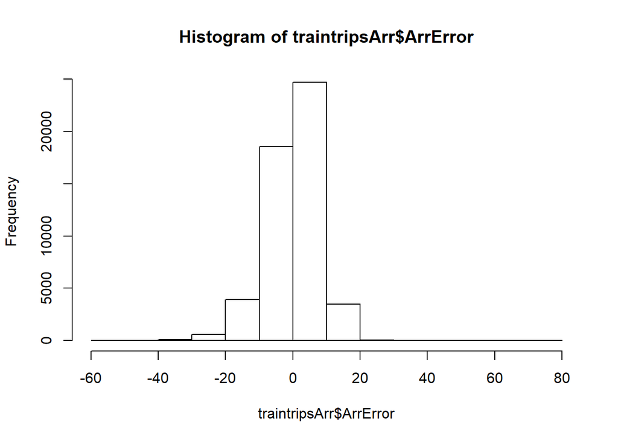

```r
# Check residual plots
hist(traintripsArr$ArrError)
```

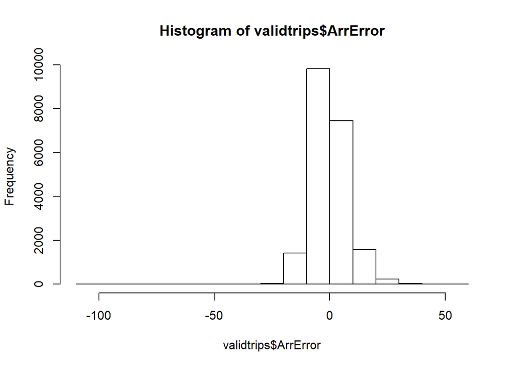

```r
hist(validtrips$ArrError)
```

In both cases the histogram is centered at zero. Espicially with Test data. This is a good test. Follows nornal distribution which is a good measure of model performance.

#### Correlation

```r
a<-cor(traintripsArr$ArrDelay,
       traintripsArr$pred.ArrDelay )
b<-cor(validtrips$ArrDelay,
       validtrips$predict.ArrDelay )
a
```

```
## [1] 0.9869709
```

```r
b
```

```
## [1] 0.9870896
```

```r
a*a
```

```
## [1] 0.9741115
```

```r
b*b
```

```
## [1] 0.9743459
```

co-relation between actul and predicted is very high satisfying the accuracy of the model.

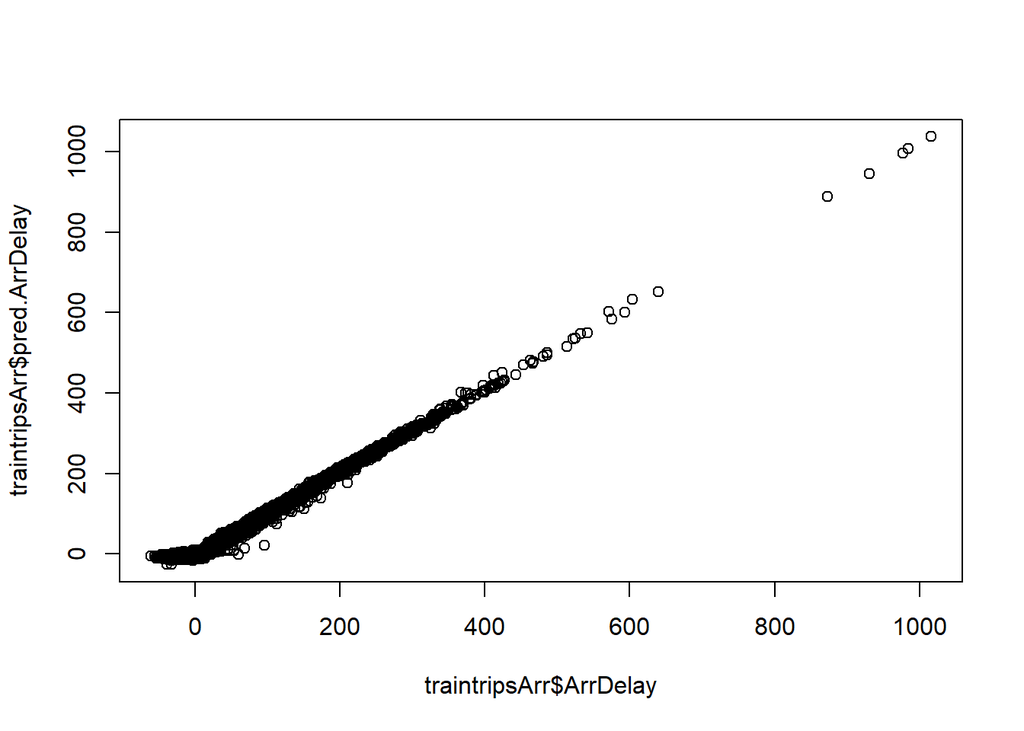

```r
plot(traintripsArr$ArrDelay,
     traintripsArr$pred.ArrDelay )
```

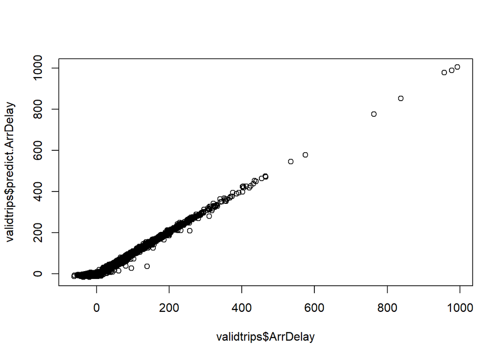

```r
plot(validtrips$ArrDelay,
     validtrips$predict.ArrDelay )
```

If we look at the Actual vs Predicted it almost follows stright line over diaognal.

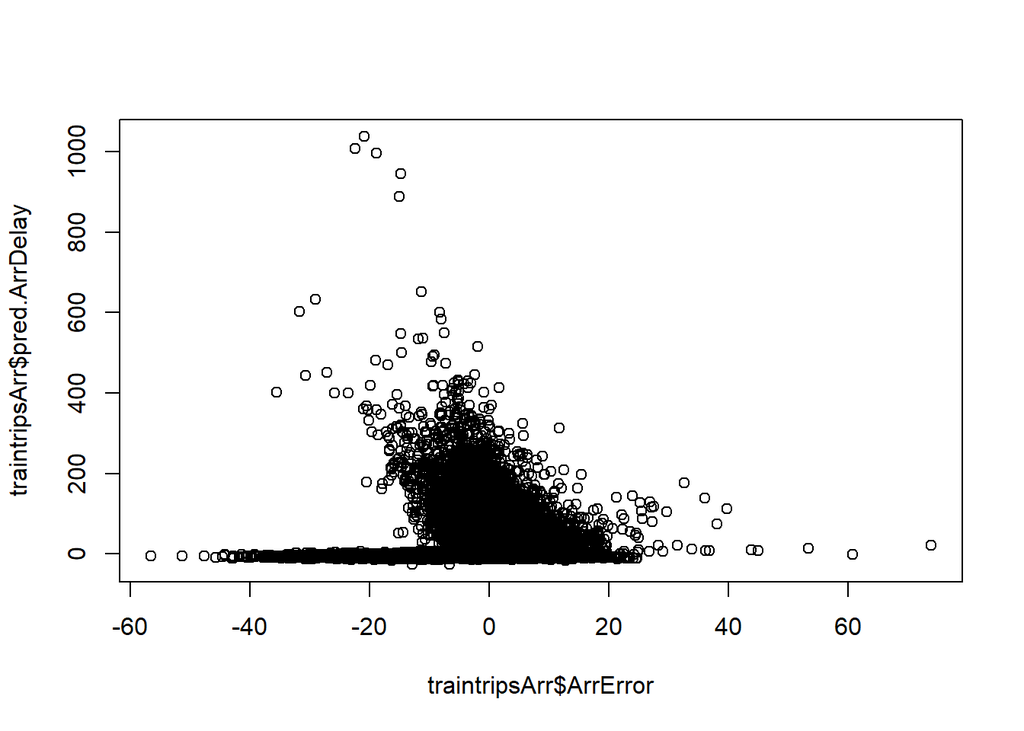

```r
plot(traintripsArr$ArrError,
     traintripsArr$pred.ArrDelay )
```

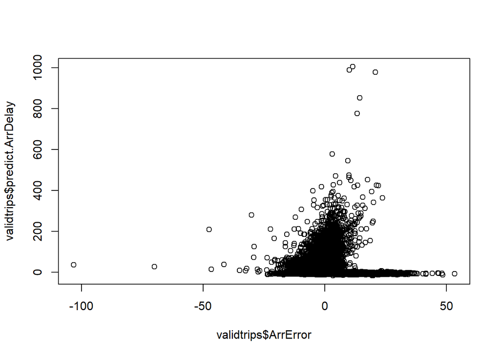

```r
plot(validtrips$ArrError,
     validtrips$predict.ArrDelay )
```

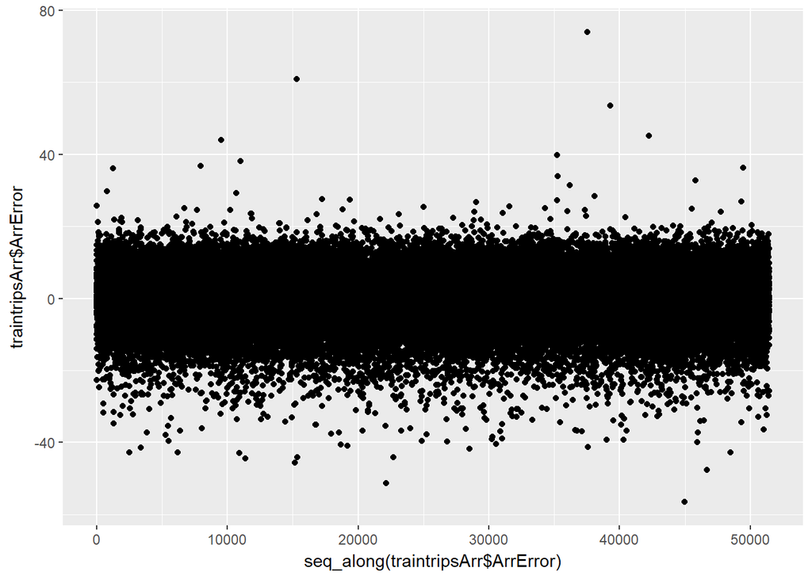

```r
qplot(y=traintripsArr$ArrError)
```

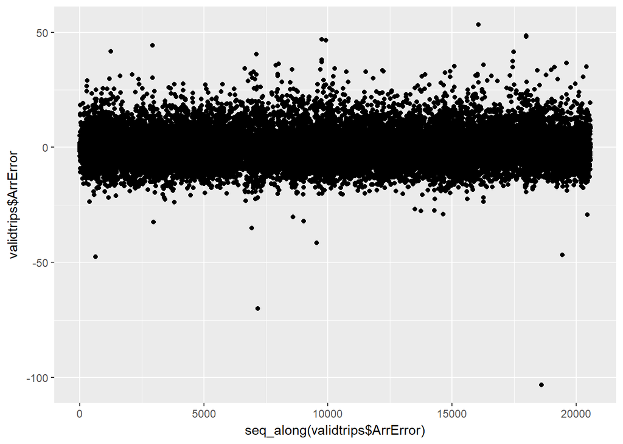

```r
qplot(y=validtrips$ArrError)
```

Follows normal distributuon. #### Model performance is good and accuracy is good as well.

#### We can try removing DepDelay (independent variable) and try and predict the ArrDelay.

Not showing all the plotsto sae some realestate. But in actual code file, we have it.

[output not shown]

[output cut: 86 more lines]

```
## [1] 209
```

```
##
## Call:
## stats::lm(formula = ArrDelay ~ ., data = traintripsArr)
##
## Residuals:
##     Min      1Q  Median      3Q     Max
## -55.638  -3.590   1.089   3.880 101.060
##
## Coefficients: (14 not defined because of singularities)
##                              Estimate Std. Error t value Pr(>|t|)
## (Intercept)                 16.290546   1.343658  12.124  < 2e-16 ***
## `as.factor(Month)2`          0.292243   0.175513   1.665 0.095903 .
## `as.factor(Month)3`         -0.370184   0.169660  -2.182 0.029120 *
## `as.factor(Month)4`         -0.392788   0.174329  -2.253 0.024255 *
## `as.factor(Month)5`         -0.316617   0.171500  -1.846 0.064874 .
## `as.factor(Month)6`          0.501798   0.169988   2.952 0.003159 **
## `as.factor(Month)7`          0.363985   0.169592   2.146 0.031859 *
## `as.factor(Month)8`          0.059653   0.171448   0.348 0.727889
## `as.factor(Month)9`         -1.462139   0.176856  -8.267  < 2e-16 ***
## `as.factor(Month)10`        -0.779053   0.174541  -4.463 8.08e-06 ***
## `as.factor(Month)11`        -1.287791   0.177251  -7.265 3.77e-13 ***
## `as.factor(Month)12`         0.297152   0.171469   1.733 0.083107 .
## `as.factor(DayOfWeek)2`     -0.512098   0.127893  -4.004 6.23e-05 ***
## `as.factor(DayOfWeek)3`     -0.011136   0.127253  -0.088 0.930267
## `as.factor(DayOfWeek)4`      0.418770   0.126945   3.299 0.000972 ***
## `as.factor(DayOfWeek)5`      0.456748   0.126357   3.615 0.000301 ***
## `as.factor(DayOfWeek)6`     -0.966667   0.132909  -7.273 3.56e-13 ***
## `as.factor(DayOfWeek)7`     -0.139899   0.128644  -1.087 0.276827
## UniqueCarrierAQ             -0.827539   0.678509  -1.220 0.222606
## UniqueCarrierAS             -0.824766   0.361717  -2.280 0.022603 *
## UniqueCarrierB6             -1.019289   0.279666  -3.645 0.000268 ***
## UniqueCarrierCO             -0.802340   0.232644  -3.449 0.000564 ***
## UniqueCarrierDL             -0.098321   0.244097  -0.403 0.687100
## UniqueCarrierEV              0.284015   0.293308   0.968 0.332891
## UniqueCarrierF9              1.418076   0.350451   4.046 5.21e-05 ***
## UniqueCarrierFL              0.246995   0.268889   0.919 0.358320
## UniqueCarrierHA              0.923849   0.599393   1.541 0.123248
## UniqueCarrierMQ              0.668557   0.207836   3.217 0.001297 **
## UniqueCarrierNW              1.603243   0.280601   5.714 1.11e-08 ***
## UniqueCarrierOH              0.803542   0.291545   2.756 0.005851 **
```

[output cut: 168 more lines]

```
## `as.factor(Originstate)WA`   2.415112   0.609043   3.965 7.34e-05 ***
## `as.factor(Originstate)WI`   0.657986   0.716682   0.918 0.358571
## `as.factor(Originstate)WV`  -0.737125   1.784501  -0.413 0.679557
## `as.factor(Originstate)WY`   0.867188   1.175108   0.738 0.460540
## TaxiOut                      1.560230   0.043370  35.974  < 2e-16 ***
## CarrierDelay                24.859174   0.035408 702.082  < 2e-16 ***
## WeatherDelay                11.429379   0.036581 312.441  < 2e-16 ***
## NASDelay                    21.515254   0.041353 520.278  < 2e-16 ***
## LateAircraftDelay           28.096939   0.036306 773.892  < 2e-16 ***
## ---
## Signif. codes:  0 '***' 0.001 '**' 0.01 '*' 0.05 '.' 0.1 ' ' 1
##
## Residual standard error: 7.846 on 51249 degrees of freedom
## Multiple R-squared:  0.9708, Adjusted R-squared:  0.9706
## F-statistic:  8860 on 192 and 51249 DF,  p-value: < 2.2e-16
```

It may predict well on Validation data set.

#### Even here model performance is good and accuracy is good as well.

#### We can use eaither of the models. If it is for predicting much earlier say week before the flight, then we don’t have DepDelay info so we can use second on. But if you are using for realtime flight delay prediction than we can use first one.

#### Finally, we need to apply this model to test data set to see the results.

### And once this is ready, we need to use the final model in function which accepts these input variables as parameters and predicts the delay.

### For Departure.

```r
#  Predict values on test set
testtrips$predict.DepDelay <- predict(lm.dep.fit1,
                                       newdata=testtrips)
```

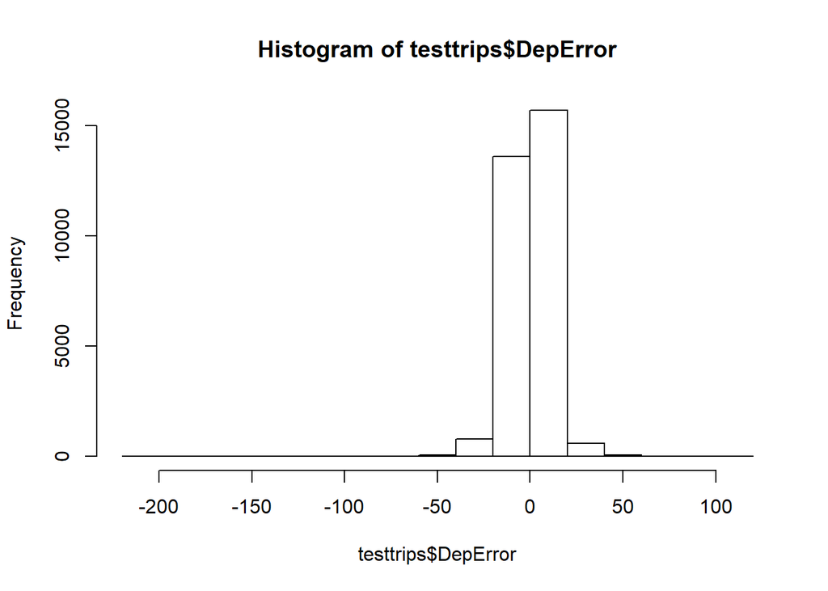

```r
testtrips$DepError <-
  testtrips$predict.DepDelay - testtrips$DepDelay


hist(testtrips$DepError)
```

### For Arrival.

```r
#  Predict values on test set
testtrips$predict.ArrDelay <- predict(lm.arr.fit2,
                                       newdata=testtrips)
```

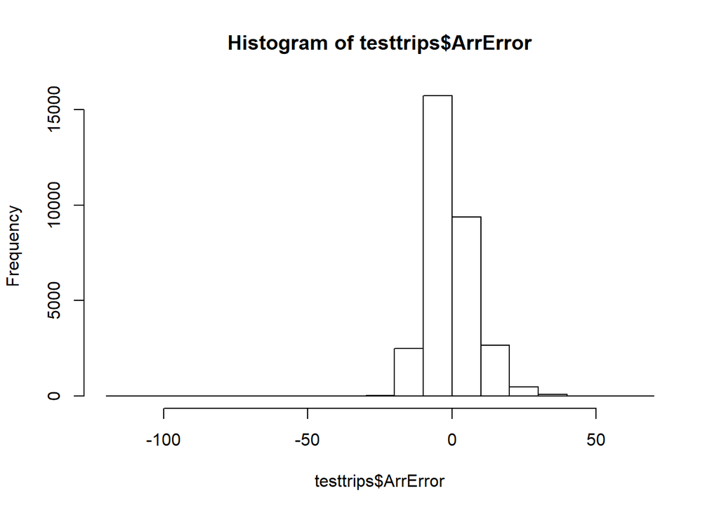

```r
testtrips$ArrError <-
  testtrips$predict.ArrDelay - testtrips$ArrDelay

hist(testtrips$ArrError)
```

This is a good test. Follows nornal distribution which is a good measure of model performance.

#### Accuracy is good for test data set as well. Too many plots. Let’s stop here.

### So the model coosen for production are lm.dep.fita for Departure and lm.arr.fit2 for Arrival.

### Now let’s answer some other questions.

## Can you detect cascading failures as delays in one airport create delays in others?

## Are there critical links in the system?

Now let’s take e.g: Let’s Say. Delays (Both ArrDelay and DepDelay) in Origin at a given time can cause Delays in later time at Dependent Dest.

So need to have mean delays by time at both Upstream Airports and downstream airports and join the.

```r
library(dplyr)

DownstreamAirport <- dplyr::select (tripsplaneairports, Origin, Dest, DepDelay, ArrDelay, DepTimeofday, ArrTimeofday, ArrHour, DepHour )

DownstreamAirportDepDelay <- DownstreamAirport %>%
  group_by( Dest, ArrHour  ) %>%
  summarise( DSAPDepDelay = mean(DepDelay))

DownstreamAirportArrDelay <- DownstreamAirport %>%
  group_by( Origin, DepHour  ) %>%
  summarise( DSAPArrDelay = mean(ArrDelay))

# Now lets join

DownstreamAirportDelays <- merge(x=DownstreamAirportDepDelay, y=DownstreamAirportArrDelay, by.x = c("Dest", "ArrHour"), by.y= c("Origin", "DepHour"))

head(DownstreamAirportDelays)
```

```
##   Dest ArrHour DSAPDepDelay DSAPArrDelay
## 1  ABE      12    12.142857    -1.300000
## 2  ABE      14     4.000000     1.285714
## 3  ABE      16     8.333333   276.000000
## 4  ABE      17    10.538462    17.692308
## 5  ABE       9    12.666667    22.000000
## 6  ABI      11    91.000000    83.000000
```

```r
colnames(DownstreamAirportDelays) <- c("DownStreamAirport",  "Hour", "DSAPDepDelay", "DSAPArrDelay" )

# Upstream Airport
UpstreamAp <- dplyr::select (tripsplaneairports, Origin, Dest, DepDelay, ArrDelay, DepTimeofday, ArrTimeofday, ArrHour, DepHour )

  UpstreamAirportDepDelay <- UpstreamAp %>%
    group_by( Dest, ArrHour  ) %>%
    summarise( DSAPDepDelay = mean(DepDelay))

  UpstreamAirportArrDelay <- UpstreamAp %>%
    group_by( Origin, DepHour  ) %>%
    summarise( DSAPArrDelay = mean(ArrDelay))

  # Now lets join

  UpstreamAirportDelays <- merge(x=UpstreamAirportDepDelay, y=UpstreamAirportArrDelay, by.x = c("Dest", "ArrHour"), by.y= c("Origin", "DepHour"))

  colnames(UpstreamAirportDelays) <- c("UpstreamAirport",  "UpstreamHour", "UPAPDepDelay", "UPAPArrDelay" )


# Link between downstream airport and upstream airport
UpstreamDownStreamLink <- UpstreamAp %>%
  group_by( Origin, Dest, DepHour, ArrHour  ) %>%
  summarise( MeanDepDelay = mean(DepDelay), MeanArrDelay= mean(ArrDelay))

# Linking Downstream Airport and Link table
DownStreamUpstreamDelaySummary <- merge(x=DownstreamAirportDelays, y=UpstreamDownStreamLink, by.x = c("DownStreamAirport", "Hour"), by.y= c("Dest", "ArrHour"))

head(DownStreamUpstreamDelaySummary)
```

```
##   DownStreamAirport Hour DSAPDepDelay DSAPArrDelay Origin DepHour
## 1               ABE   12    12.142857    -1.300000    CVG      11
## 2               ABE   12    12.142857    -1.300000    CLE      11
## 3               ABE   12    12.142857    -1.300000    CVG      10
## 4               ABE   14     4.000000     1.285714    ATL      12
## 5               ABE   16     8.333333   276.000000    ORD      13
## 6               ABE   16     8.333333   276.000000    CLE      15
##   MeanDepDelay MeanArrDelay
## 1     2.666667    -5.000000
## 2    -7.000000   -13.000000
## 3    28.000000    17.666667
## 4     4.000000    20.500000
## 5    18.600000    15.400000
## 6    -5.666667    -7.666667
```

```r
# Now link to upstream airport

DownStreamUpstreamDelaySummaryfinal <- merge( x=UpstreamAirportDelays, y=DownStreamUpstreamDelaySummary, by.y = c("Origin", "DepHour") , by.x= c("UpstreamAirport",  "UpstreamHour"))

CascadingSummary <- DownStreamUpstreamDelaySummaryfinal %>%
                    group_by(DownStreamAirport, Hour )  %>%
                    summarize(DSAPDelay = mean(DSAPDepDelay+DSAPArrDelay), UPAPDelay = mean(UPAPDepDelay+UPAPDepDelay), MeanDSAPDepDelay = mean(DSAPDepDelay), MeanDSAPArrDelay = mean(DSAPArrDelay) , MeanUPAPDepDelay =  mean(UPAPDepDelay), MeanUPAPDelay = mean(UPAPArrDelay) ) %>%
                    filter (DSAPDelay > -121 , DSAPDelay < 121 , UPAPDelay > -121  , UPAPDelay < 121 )
                    # Filering to avoid outliers... some which are more then 300min delays, these have different #reasons...

head(CascadingSummary)
```

```
## # A tibble: 6 x 8
## # Groups:   DownStreamAirport [3]
##   DownStreamAirport  Hour  DSAPDelay UPAPDelay MeanDSAPDepDelay
##              <fctr> <dbl>      <dbl>     <dbl>            <dbl>
## 1               ABE     9  34.666667  1.786667         12.66667
## 2               ABE    12  10.842857 12.462862         12.14286
## 3               ABE    14   5.285714 26.403509          4.00000
## 4               ABE    17  28.230769 35.258005         10.53846
## 5               ABI    17  53.250000 44.532751         33.25000
## 6               ABQ     0 -13.000000 53.292453         -6.00000
## # ... with 3 more variables: MeanDSAPArrDelay <dbl>,
## #   MeanUPAPDepDelay <dbl>, MeanUPAPDelay <dbl>
```

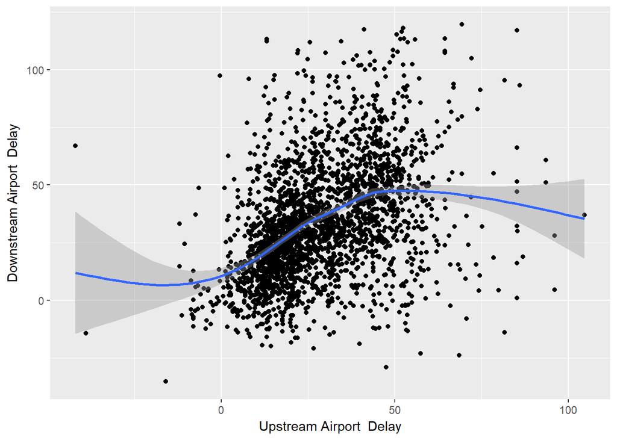

```r
ggplot(CascadingSummary, aes(UPAPDelay, DSAPDelay)) + geom_point() + geom_smooth() + xlab("Upstream Airport  Delay") + ylab("Downstream Airport  Delay")
```

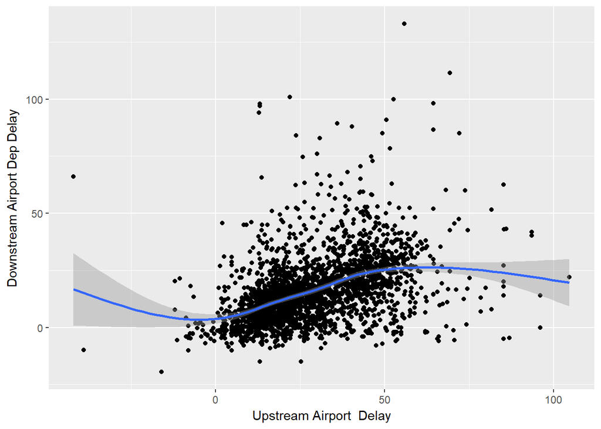

```r
ggplot(CascadingSummary, aes(UPAPDelay, MeanDSAPDepDelay)) + geom_point() + geom_smooth() + xlab("Upstream Airport  Delay") + ylab("Downstream Airport Dep Delay")
```

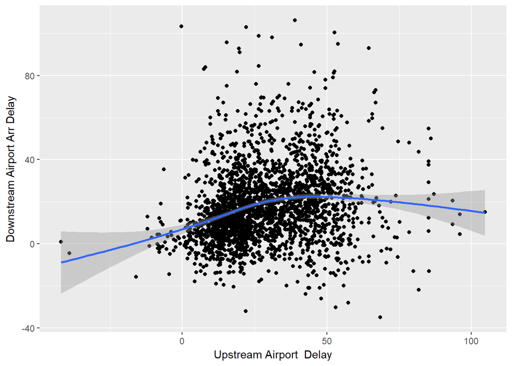

```r
ggplot(CascadingSummary, aes(UPAPDelay, MeanDSAPArrDelay)) + geom_point() + geom_smooth() + xlab("Upstream Airport  Delay") + ylab("Downstream Airport Arr Delay")
```

```r
# We can clearly see relationship
# Let's look into co-relation

cor(CascadingSummary$DSAPDelay, CascadingSummary$UPAPDelay )
```

```
## [1] 0.4007824
```

### We can see positive co-relation ~0.40, It may be a good predictor. This would definitely improve if we add more parameters such as day of the week etc…

## Let’s say we want to include UPAPDelay as parameter for predicting Delays. We can write a function.

```r
AascadingAirportDelay <- function(DownstreamAirportval, DownStreamExpHourval ) {

   DownstreamAirportDepDelay <- tripsplaneairports %>%
    filter( Dest == DownstreamAirportval , ArrHour == DownStreamExpHourval ) %>%
    group_by( Dest, ArrHour  ) %>%
    summarise( DSAPDepDelay = mean(DepDelay))

  DownstreamAirportArrDelay <- tripsplaneairports %>%
    filter( Origin == DownstreamAirportval , DepHour == DownStreamExpHourval ) %>%
    group_by( Origin, DepHour  ) %>%
    summarise( DSAPArrDelay = mean(ArrDelay))

  # Now lets join

  DownstreamAirportDelays <- merge(x=DownstreamAirportDepDelay, y=DownstreamAirportArrDelay, by.x = c("Dest", "ArrHour"), by.y= c("Origin", "DepHour"))

  colnames(DownstreamAirportDelays) <- c("DownStreamAirport",  "Hour", "DSAPDepDelay", "DSAPArrDelay" )

  # Upstream Airport

  UpstreamAp <- dplyr::select (tripsplaneairports, Origin, Dest, DepDelay, ArrDelay, DepTimeofday, ArrTimeofday, ArrHour, DepHour )

  UpstreamAirportDepDelay <- UpstreamAp %>%
    group_by( Dest, ArrHour  ) %>%
    summarise( DSAPDepDelay = mean(DepDelay))

  UpstreamAirportArrDelay <- UpstreamAp %>%
    group_by( Origin, DepHour  ) %>%
    summarise( DSAPArrDelay = mean(ArrDelay))

  # Now lets join

  UpstreamAirportDelays <- merge(x=UpstreamAirportDepDelay, y=UpstreamAirportArrDelay, by.x = c("Dest", "ArrHour"), by.y= c("Origin", "DepHour"))

  colnames(UpstreamAirportDelays) <- c("UpstreamAirport",  "UpstreamHour", "UPAPDepDelay", "UPAPArrDelay" )

  # Link between downstream airport and upstream airport

  UpstreamDownStreamLink <- UpstreamAp %>%
    group_by( Origin, Dest, DepHour, ArrHour  ) %>%
    summarise( MeanDepDelay = mean(DepDelay), MeanArrDelay= mean(ArrDelay))

  # Linking Downstream Airport and Link table
  DownStreamUpstreamDelaySummary <- merge(x=DownstreamAirportDelays, y=UpstreamDownStreamLink, by.x = c("DownStreamAirport", "Hour"), by.y= c("Dest", "ArrHour"))

  # Now link to upstream airport

  DownStreamUpstreamDelaySummaryfinal <- merge( x=UpstreamAirportDelays, y=DownStreamUpstreamDelaySummary, by.y = c("Origin", "DepHour") , by.x= c("UpstreamAirport",  "UpstreamHour"))

  head(DownStreamUpstreamDelaySummaryfinal)

  CascadingSummary <- DownStreamUpstreamDelaySummaryfinal %>%
    group_by(DownStreamAirport, Hour )  %>%
    summarize(DSAPDelay = mean(DSAPDepDelay+DSAPArrDelay), UPAPDelay = mean(UPAPDepDelay+UPAPDepDelay), mean(DSAPDepDelay), mean(DSAPArrDelay) , mean(UPAPDepDelay), mean(UPAPArrDelay) )

return(if (is_empty(CascadingSummary$UPAPDelay ) ) {0}
else
{
CascadingSummary$UPAPDelay
}
)

}
```

#### Now we can run the function to see how we are able to get MeanUpstreamAirport Delay, By passing Dependent Airport and an hour of interest.

```r
AascadingAirportDelay ("ABE", 12 )
```

```
## [1] 12.46286
```

```r
AascadingAirportDelay ("ABE", 10 )
```

```
## [1] 0
```

#### We can use this to create additional feature in the data set. Only in training data set.

#### In test data set, however this variable will not be available upfront.. i.e This can be used to predict flight delays closer to the time of flying because that is the time the delays in Upstream Airports will be available.

```r
#newtripsplaneairports <- trips %>%  mutate( UpstreamAirportMeanDelay = mapply(AascadingAirportDelay, Dest, ArrHour ))

# Not running this because this goes for loops and takes long time to execute.
```

###### Now we can use this variable “UpstreamAirportMeanDelay” as a feature to predict flight delays.

###### This ends our Analysis… Below we try to explore the same concepts on Big Data Spark systems.

## Running same analysis on BigData/Spark

#### Connecting to Spark Local server

```r
sc <- spark_connect(master = "local")
```

## Exploratory Data Analysis

### Carrier on-time performance

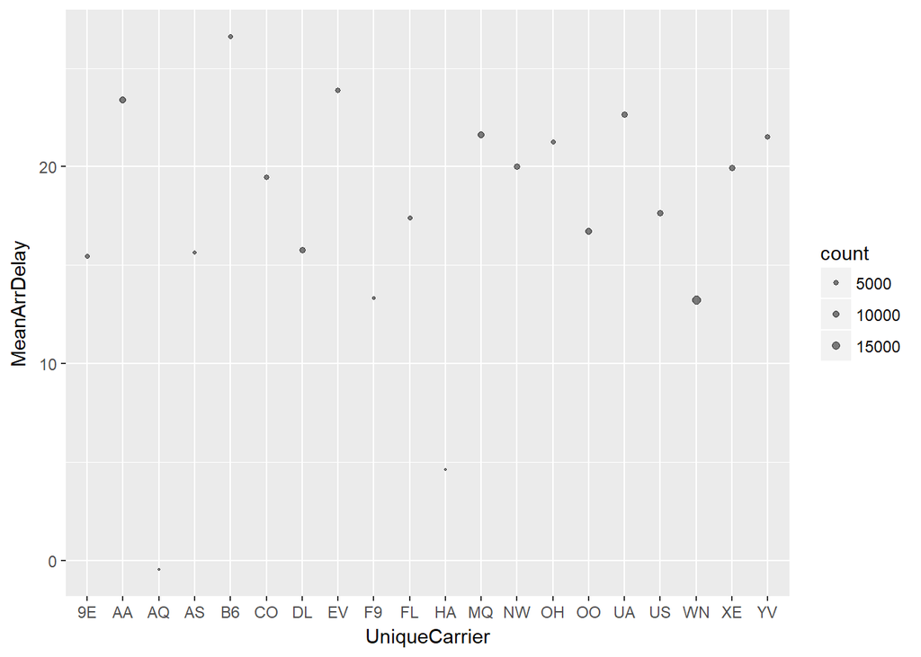

```r
tripsdelayCarrier <- trips_tbl2 %>%
  group_by(UniqueCarrier) %>%
  summarise(count=n(), MeanArrDelay=mean(ArrDelay), MeanDepdelay=mean(DepDelay)) %>%
  filter (count > 20 ) %>%
  collect
#Plot the delay

ggplot(tripsdelayCarrier, aes(UniqueCarrier, MeanArrDelay)) + geom_point(aes(size=count), alpha=1/2) + scale_size_area(max_size = 2)
```

### Delays in each month

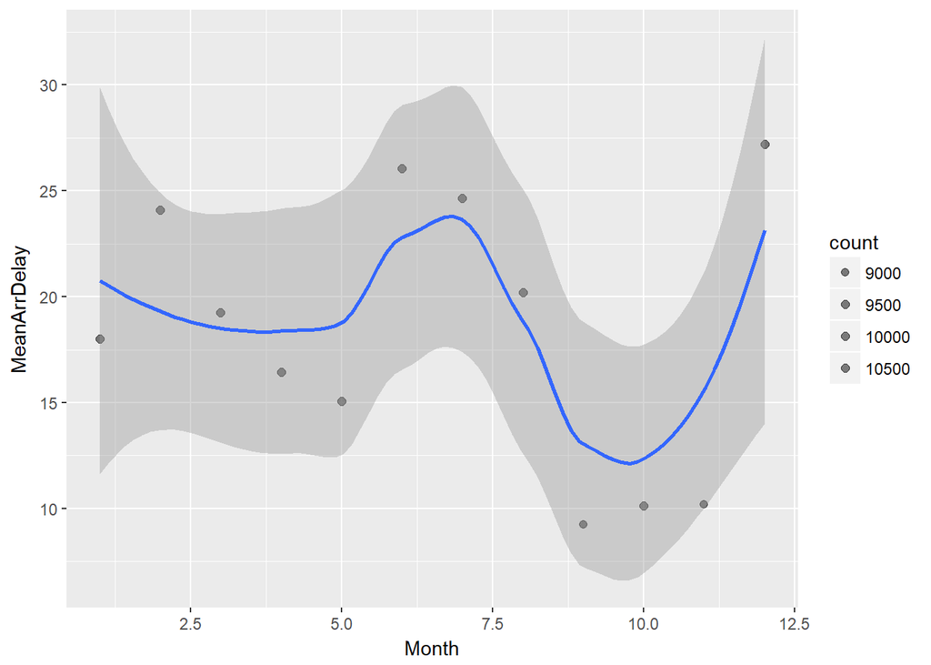

```r
tripsdelayMonth <- trips_tbl2 %>%
  group_by(Month) %>%
  summarise(count=n(), MeanArrDelay=mean(ArrDelay), MeanDepdelay=mean(DepDelay)) %>%
  filter (count > 20 ) %>%
  collect
#Plot the delay

ggplot(tripsdelayMonth, aes(Month, MeanArrDelay)) + geom_point(aes(size=count), alpha=1/2) + geom_smooth() + scale_size_area(max_size = 2)
```

### Linear regression with Spark ML Lib (Just an example)

Summarize the linear model

```r
summary(mlfit1)
```

```
## Call: ml_linear_regression(., DepDelay ~ WeatherDelay + Month)
##
## Deviance Residuals::
##      Min       1Q   Median       3Q      Max
## -225.061  -20.215  -16.215    3.313 1161.368
##
## Coefficients:
##               Estimate Std. Error t value  Pr(>|t|)
## (Intercept)  17.947012   0.314325 57.0970 < 2.2e-16 ***
## WeatherDelay  0.996885   0.012572 79.2940 < 2.2e-16 ***
## Month        -0.157499   0.043008 -3.6621 0.0002503 ***
## ---
## Signif. codes:  0 '***' 0.001 '**' 0.01 '*' 0.05 '.' 0.1 ' ' 1
##
## R-Squared: 0.06991
## Root Mean Squared Error: 42.75
```

From results it’s clear that we don’t necessirly have choosen all the features. We can continue same steps we did on R on spark environment as well and surely we will have similar results. Leaving this here given my Spark session terminates frequently and RStudio behaving not as expected.

## Conclusion:

It’s a great experience to know what goes behind the screen in flying….. so much fun… and so much more to do before this can be used in real-time.

### Future imporovements and suggestios

1. We have taken only sample data hence peformance possibly be enhanced by running same analysis on Spark. But steps wouldn’t change much.
2. We have had 29 + another 10 + varlables to work with. So tried testing each and every variable and it’s significance. We could try Principal Component Analysis and then use the principal comonents to predict outcome.
3. We can also pre-define what is delay, i.e more then certain minutes as delay (e.g: more then 10min as delay) and turn this into Classification problem. And once classified then start predicting the delay minutes using linear regression. To check if there is alternates that can add value.
4. Airport Cascading delays, precalculated transformed features can be used in model prediction.
5. Some of the delays such as CarrierDelay etc.. are realtime hence while using this model in production we need to eaither get mean values for a given criteria from historical data and use in prediction or build different model.
6. Before using this model in production, there is some work to be done listed above. And ofcourse, we need to modularize the code and create functions for all repetative tasks. Also, create functions to answer questions.